# “Data Analysis Techniques Visualization for Breast Cancer Prediction and Classification with High Accuracy Rates”

###### Presented To: Dr. Mustafa Elattar , Eng.Aly abdelmageed

# Team Names:

###### Shrouk Hesham 19106271

###### Omnia salah 19106208

###### Hussin Fekry 19105777

###### Abdelrahman Mahmoud Mari 19104609

###### Asmaa Mohamed Elmaghraby 19200036

###### Toqa Hamdy 19105665

# Load Libraries

```python
import numpy as np
import pandas as pd
import seaborn as sns
import matplotlib.pyplot as plt
import matplotlib.gridspec as gridspec
from matplotlib.colors import ListedColormap
%matplotlib inline
```

```python
from sklearn.preprocessing import StandardScaler
from sklearn.model_selection import train_test_split, GridSearchCV, KFold
from sklearn.linear_model import LogisticRegression
from sklearn.metrics import accuracy_score, confusion_matrix
from sklearn.neighbors import KNeighborsClassifier, NeighborhoodComponentsAnalysis, LocalOutlierFactor
from sklearn.decomposition import PCA
from sklearn.ensemble import RandomForestClassifier
from sklearn.tree import DecisionTreeClassifier, export_graphviz
from sklearn import metrics
```

# Load the data

```python
data = pd.read_csv("data.csv")
```

```python
data.head()
```

|  | id | diagnosis | radius_mean | texture_mean | perimeter_mean | area_mean | smoothness_mean | compactness_mean | concavity_mean | concave points_mean | ... | texture_worst | perimeter_worst | area_worst | smoothness_worst | compactness_worst | concavity_worst | concave points_worst | symmetry_worst | fractal_dimension_worst | Unnamed: 32 |
| --- | --- | --- | --- | --- | --- | --- | --- | --- | --- | --- | --- | --- | --- | --- | --- | --- | --- | --- | --- | --- | --- |
| 0 | 842302 | M | 17.99 | 10.38 | 122.80 | 1001.0 | 0.11840 | 0.27760 | 0.3001 | 0.14710 | ... | 17.33 | 184.60 | 2019.0 | 0.1622 | 0.6656 | 0.7119 | 0.2654 | 0.4601 | 0.11890 | NaN |
| 1 | 842517 | M | 20.57 | 17.77 | 132.90 | 1326.0 | 0.08474 | 0.07864 | 0.0869 | 0.07017 | ... | 23.41 | 158.80 | 1956.0 | 0.1238 | 0.1866 | 0.2416 | 0.1860 | 0.2750 | 0.08902 | NaN |
| 2 | 84300903 | M | 19.69 | 21.25 | 130.00 | 1203.0 | 0.10960 | 0.15990 | 0.1974 | 0.12790 | ... | 25.53 | 152.50 | 1709.0 | 0.1444 | 0.4245 | 0.4504 | 0.2430 | 0.3613 | 0.08758 | NaN |
| 3 | 84348301 | M | 11.42 | 20.38 | 77.58 | 386.1 | 0.14250 | 0.28390 | 0.2414 | 0.10520 | ... | 26.50 | 98.87 | 567.7 | 0.2098 | 0.8663 | 0.6869 | 0.2575 | 0.6638 | 0.17300 | NaN |
| 4 | 84358402 | M | 20.29 | 14.34 | 135.10 | 1297.0 | 0.10030 | 0.13280 | 0.1980 | 0.10430 | ... | 16.67 | 152.20 | 1575.0 | 0.1374 | 0.2050 | 0.4000 | 0.1625 | 0.2364 | 0.07678 | NaN |

5 rows × 33 columns

```python
data.describe()
```

|  | id | radius_mean | texture_mean | perimeter_mean | area_mean | smoothness_mean | compactness_mean | concavity_mean | concave points_mean | symmetry_mean | ... | texture_worst | perimeter_worst | area_worst | smoothness_worst | compactness_worst | concavity_worst | concave points_worst | symmetry_worst | fractal_dimension_worst | Unnamed: 32 |
| --- | --- | --- | --- | --- | --- | --- | --- | --- | --- | --- | --- | --- | --- | --- | --- | --- | --- | --- | --- | --- | --- |
| count | 5.690000e+02 | 569.000000 | 569.000000 | 569.000000 | 569.000000 | 569.000000 | 569.000000 | 569.000000 | 569.000000 | 569.000000 | ... | 569.000000 | 569.000000 | 569.000000 | 569.000000 | 569.000000 | 569.000000 | 569.000000 | 569.000000 | 569.000000 | 0.0 |
| mean | 3.037183e+07 | 14.127292 | 19.289649 | 91.969033 | 654.889104 | 0.096360 | 0.104341 | 0.088799 | 0.048919 | 0.181162 | ... | 25.677223 | 107.261213 | 880.583128 | 0.132369 | 0.254265 | 0.272188 | 0.114606 | 0.290076 | 0.083946 | NaN |
| std | 1.250206e+08 | 3.524049 | 4.301036 | 24.298981 | 351.914129 | 0.014064 | 0.052813 | 0.079720 | 0.038803 | 0.027414 | ... | 6.146258 | 33.602542 | 569.356993 | 0.022832 | 0.157336 | 0.208624 | 0.065732 | 0.061867 | 0.018061 | NaN |
| min | 8.670000e+03 | 6.981000 | 9.710000 | 43.790000 | 143.500000 | 0.052630 | 0.019380 | 0.000000 | 0.000000 | 0.106000 | ... | 12.020000 | 50.410000 | 185.200000 | 0.071170 | 0.027290 | 0.000000 | 0.000000 | 0.156500 | 0.055040 | NaN |
| 25% | 8.692180e+05 | 11.700000 | 16.170000 | 75.170000 | 420.300000 | 0.086370 | 0.064920 | 0.029560 | 0.020310 | 0.161900 | ... | 21.080000 | 84.110000 | 515.300000 | 0.116600 | 0.147200 | 0.114500 | 0.064930 | 0.250400 | 0.071460 | NaN |
| 50% | 9.060240e+05 | 13.370000 | 18.840000 | 86.240000 | 551.100000 | 0.095870 | 0.092630 | 0.061540 | 0.033500 | 0.179200 | ... | 25.410000 | 97.660000 | 686.500000 | 0.131300 | 0.211900 | 0.226700 | 0.099930 | 0.282200 | 0.080040 | NaN |
| 75% | 8.813129e+06 | 15.780000 | 21.800000 | 104.100000 | 782.700000 | 0.105300 | 0.130400 | 0.130700 | 0.074000 | 0.195700 | ... | 29.720000 | 125.400000 | 1084.000000 | 0.146000 | 0.339100 | 0.382900 | 0.161400 | 0.317900 | 0.092080 | NaN |
| max | 9.113205e+08 | 28.110000 | 39.280000 | 188.500000 | 2501.000000 | 0.163400 | 0.345400 | 0.426800 | 0.201200 | 0.304000 | ... | 49.540000 | 251.200000 | 4254.000000 | 0.222600 | 1.058000 | 1.252000 | 0.291000 | 0.663800 | 0.207500 | NaN |

8 rows × 32 columns

```python
data.info()
```

```
<class 'pandas.core.frame.DataFrame'>
RangeIndex: 569 entries, 0 to 568
Data columns (total 33 columns):
 #   Column                   Non-Null Count  Dtype
---  ------                   --------------  -----
 0   id                       569 non-null    int64
 1   diagnosis                569 non-null    object
 2   radius_mean              569 non-null    float64
 3   texture_mean             569 non-null    float64
 4   perimeter_mean           569 non-null    float64
 5   area_mean                569 non-null    float64
 6   smoothness_mean          569 non-null    float64
 7   compactness_mean         569 non-null    float64
 8   concavity_mean           569 non-null    float64
 9   concave points_mean      569 non-null    float64
```

[output cut: 25 more lines]

# Cleaning and Preparing the data

#### Since we don't need the id column and the empty Unnamed: 32 column in the dataset, we remove them.

```python
data.drop("id", axis=1, inplace=True)
```

```python
data.drop('Unnamed: 32', axis=1, inplace=True)
```

#### Let's look at the values of the column we are going to predict

```python
data.diagnosis.unique()
```

```
array(['M', 'B'], dtype=object)
```

#### Columns are initials of Malignant and Bening results. These values are not the kind our algorithms will understand. For this, we will define Malignant as 1 and Bening as 0.

```python
data.diagnosis = data['diagnosis'].map({'M':1, 'B':0})
```

# Exploratory Data Analysis

#### Let's look at the statistical information of our dataset

```python
data.describe()
```

|  | diagnosis | radius_mean | texture_mean | perimeter_mean | area_mean | smoothness_mean | compactness_mean | concavity_mean | concave points_mean | symmetry_mean | ... | radius_worst | texture_worst | perimeter_worst | area_worst | smoothness_worst | compactness_worst | concavity_worst | concave points_worst | symmetry_worst | fractal_dimension_worst |
| --- | --- | --- | --- | --- | --- | --- | --- | --- | --- | --- | --- | --- | --- | --- | --- | --- | --- | --- | --- | --- | --- |
| count | 569.000000 | 569.000000 | 569.000000 | 569.000000 | 569.000000 | 569.000000 | 569.000000 | 569.000000 | 569.000000 | 569.000000 | ... | 569.000000 | 569.000000 | 569.000000 | 569.000000 | 569.000000 | 569.000000 | 569.000000 | 569.000000 | 569.000000 | 569.000000 |
| mean | 0.372583 | 14.127292 | 19.289649 | 91.969033 | 654.889104 | 0.096360 | 0.104341 | 0.088799 | 0.048919 | 0.181162 | ... | 16.269190 | 25.677223 | 107.261213 | 880.583128 | 0.132369 | 0.254265 | 0.272188 | 0.114606 | 0.290076 | 0.083946 |
| std | 0.483918 | 3.524049 | 4.301036 | 24.298981 | 351.914129 | 0.014064 | 0.052813 | 0.079720 | 0.038803 | 0.027414 | ... | 4.833242 | 6.146258 | 33.602542 | 569.356993 | 0.022832 | 0.157336 | 0.208624 | 0.065732 | 0.061867 | 0.018061 |
| min | 0.000000 | 6.981000 | 9.710000 | 43.790000 | 143.500000 | 0.052630 | 0.019380 | 0.000000 | 0.000000 | 0.106000 | ... | 7.930000 | 12.020000 | 50.410000 | 185.200000 | 0.071170 | 0.027290 | 0.000000 | 0.000000 | 0.156500 | 0.055040 |
| 25% | 0.000000 | 11.700000 | 16.170000 | 75.170000 | 420.300000 | 0.086370 | 0.064920 | 0.029560 | 0.020310 | 0.161900 | ... | 13.010000 | 21.080000 | 84.110000 | 515.300000 | 0.116600 | 0.147200 | 0.114500 | 0.064930 | 0.250400 | 0.071460 |
| 50% | 0.000000 | 13.370000 | 18.840000 | 86.240000 | 551.100000 | 0.095870 | 0.092630 | 0.061540 | 0.033500 | 0.179200 | ... | 14.970000 | 25.410000 | 97.660000 | 686.500000 | 0.131300 | 0.211900 | 0.226700 | 0.099930 | 0.282200 | 0.080040 |
| 75% | 1.000000 | 15.780000 | 21.800000 | 104.100000 | 782.700000 | 0.105300 | 0.130400 | 0.130700 | 0.074000 | 0.195700 | ... | 18.790000 | 29.720000 | 125.400000 | 1084.000000 | 0.146000 | 0.339100 | 0.382900 | 0.161400 | 0.317900 | 0.092080 |
| max | 1.000000 | 28.110000 | 39.280000 | 188.500000 | 2501.000000 | 0.163400 | 0.345400 | 0.426800 | 0.201200 | 0.304000 | ... | 36.040000 | 49.540000 | 251.200000 | 4254.000000 | 0.222600 | 1.058000 | 1.252000 | 0.291000 | 0.663800 | 0.207500 |

8 rows × 31 columns

#### Let's look at the density of our target value

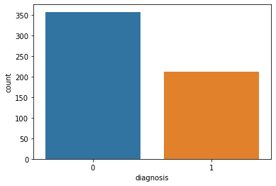

```python
sns.countplot(data["diagnosis"])
```

#### On average, 350 of our samples have benign tumors and 200 have malignant tumors.

## Correlation Matrix

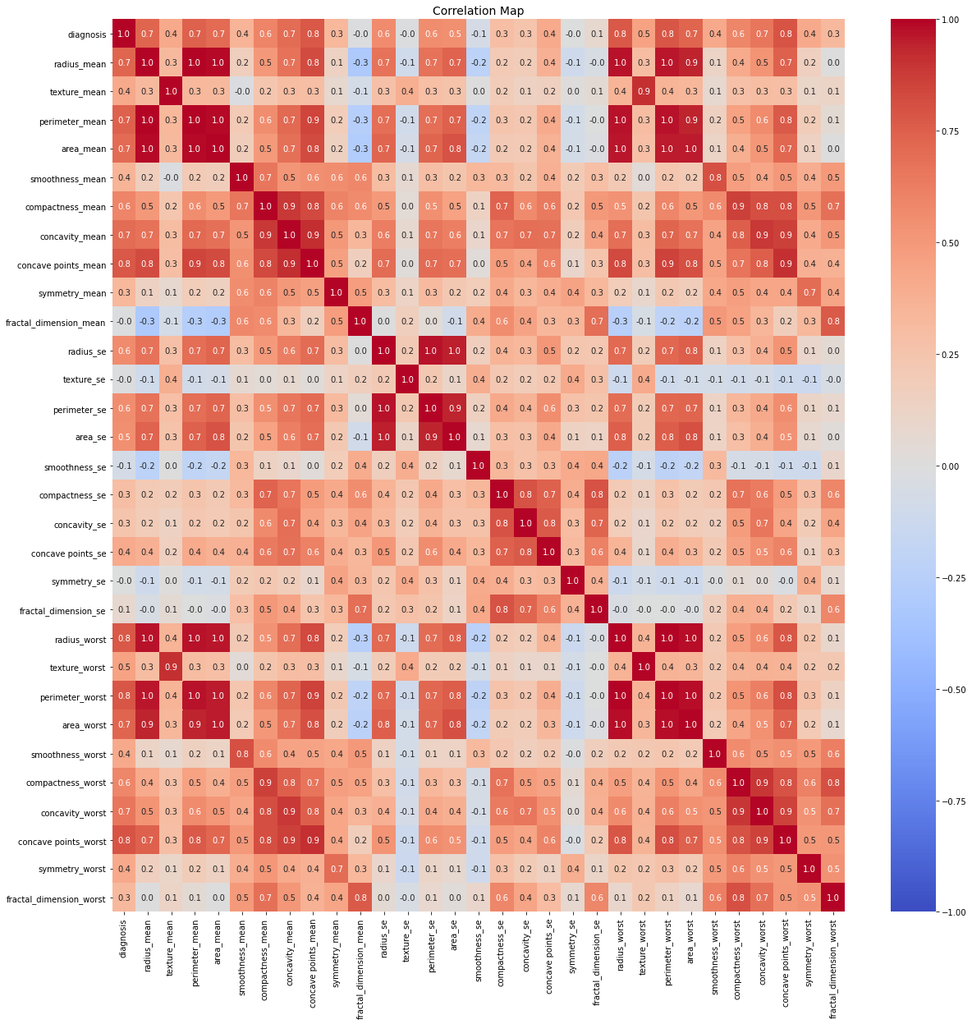

```python
f, ax = plt.subplots(figsize = (20,20))
sns.heatmap(data.corr(), annot=True, fmt='.1f',
            ax=ax, cmap='coolwarm', vmin=-1, vmax=1)
plt.xticks(rotation=90)
plt.yticks(rotation=0)
plt.title('Correlation Map', size=14);
```

#### Let's plot the traits with a correlation greater than 0.75

```python
flt = np.abs(data.corr()['diagnosis']) > .75
```

```python
corr_feat = data.corr().columns[flt].tolist()
```

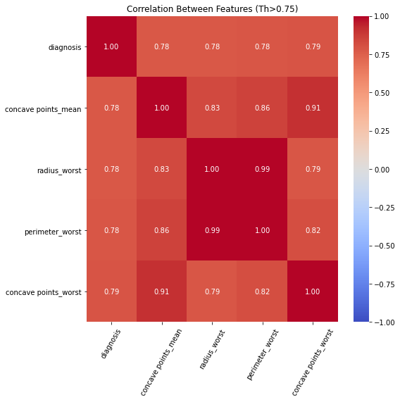

```python
f, ax = plt.subplots(figsize = (8,8))
sns.heatmap(data[corr_feat].corr(), annot=True, fmt='.2f',
           ax=ax, cmap='coolwarm',vmin=-1,vmax=1)
plt.xticks(rotation=60)
plt.yticks(rotation=0)
plt.title('Correlation Between Features (Th>0.75)');
```

#### Here we see the 5 features that are most correlated with each other. One of them is our target value. This is good

# Now let's look at the distribution of our values

```python
def melt(dataset, param):
    data_melted = pd.melt(dataset, id_vars=param,
                     var_name="features",
                     value_name="value")
    return data_melted

def boxplot(dataset, param):
    plt.figure(figsize= (14,8))
    sns.boxplot(x="features", y="value", hue=param, data=dataset)
    plt.xticks(rotation = 90)
    return plt.show()

def pairplot(dataset, param):
    sns.pairplot(dataset, diag_kind='kde', markers='+', hue=param);
```

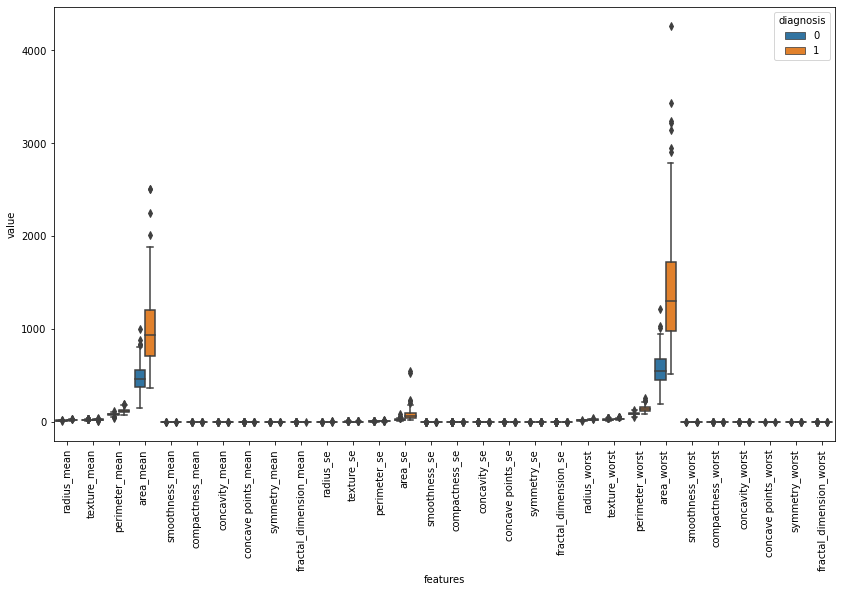

```python
boxplot(melt(data,"diagnosis"),"diagnosis")
```

#### It looks like there are outliers. If we remove them and standardize our values, we get more accurate results.

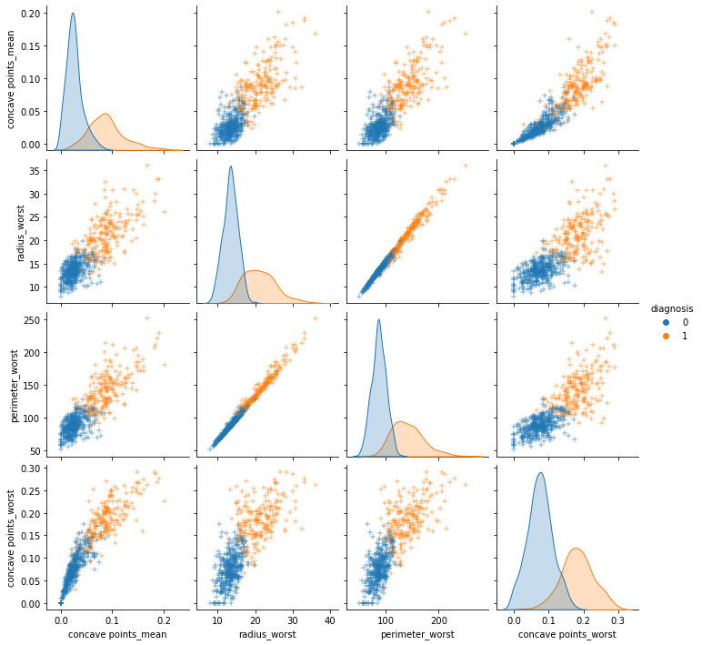

```python
pairplot(data[corr_feat],"diagnosis")
```

#### When we plot the highly correlated features by classifying them according to the target value, we see that the data with benign tumors and data with malignant tumors are grouped in separate values. In other words, the fact that one of the features we are comparing has a high value causes the other to have a high value. The analysis we will do in this way will not give exactly correct results. Because when the value of one of the features with high correlation increases, the other increases as well.

# Diagnosis vs Features

##### As a result, if we divide our data into patients and non-patients, our prediction model will give more accurate results.

```python
feat = list(data.columns[1:11])
dataM = data[data.diagnosis ==1]
dataB = data[data.diagnosis ==0]
```

##### Let's plot the distribution of the values in the features by those who are sick and those who are not.

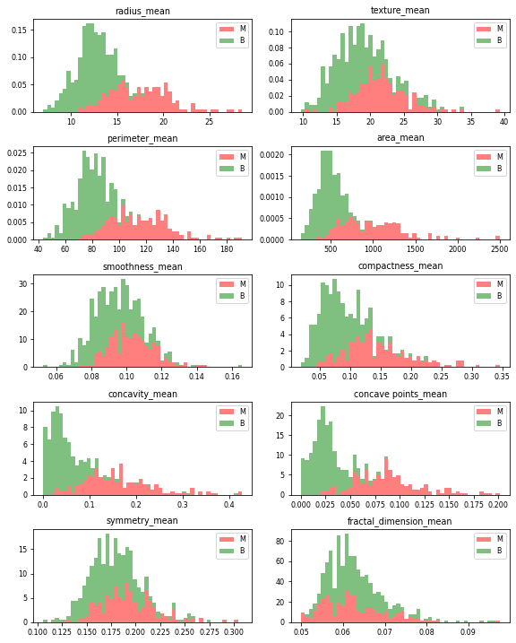

```python
plt.rcParams.update({'font.size': 8})
f, axes = plt.subplots(nrows=5, ncols=2, figsize=(8,10))
axes = axes.ravel()
for i,ax in enumerate(axes):
    ax.figure
    binwidth= (max(data[feat[i]]) - min(data[feat[i]]))/50
    ax.hist([dataM[feat[i]],dataB[feat[i]]],
            bins=np.arange(min(data[feat[i]]), max(data[feat[i]]) + binwidth, binwidth),
            alpha=0.5,stacked=True, density=True, label=['M','B'],color=['r','g'])
    ax.legend(loc='upper right')
    ax.set_title(feat[i])
plt.tight_layout()
plt.show()
```

#### Unlike the above, the mean values of cell radius, perimeter, area, compactness, concavity and concave points can be used in classification of the cancer. Larger values of these parameters tends to show a correlation with malignant tumors.

#### Mean values of texture, smoothness, symmetry or fractual dimension does not show a particular preference of one diagnosis over the other. In any of the histograms there are no noticeable large outliers that warrants further cleanup.

## Outlier Detection

##### Let's detect outliers.

```python
X = data.drop(['diagnosis'], axis=1)
y = data.diagnosis
```

```python
column = X.columns.tolist()
```

```python
LOF = LocalOutlierFactor()
y_pred = LOF.fit_predict(X)
X_score =LOF.negative_outlier_factor_
```

```python
outlier_score = pd.DataFrame()
outlier_score['score'] = X_score
outlier_score.head()
```

|  | score |
| --- | --- |
| 0 | -1.422440 |
| 1 | -1.066782 |
| 2 | -0.978948 |
| 3 | -1.596933 |
| 4 | -1.069936 |

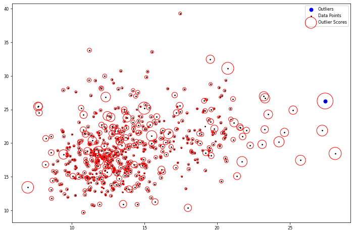

```python
radius = (X_score.max() - X_score) / (X_score.max() - X_score.min())
outlier_score["radius"] = radius
filt = outlier_score["score"] < -2.5
outlier_index = outlier_score[filt].index.tolist()
plt.figure(figsize = (12,8))
plt.scatter(X.iloc[outlier_index,0], X.iloc[outlier_index,1],
            color = "blue", s = 50, label = "Outliers" )
plt.scatter(X.iloc[:,0], X.iloc[:,1], color ="k", s=3, label = "Data Points" )
plt.scatter(X.iloc[:,0],X.iloc[:,1], s=1000*radius, edgecolor = "r",
            facecolors = "none", label="Outlier Scores")
plt.legend()
plt.show()
```

##### We see outliers. Let's remove them now

## Drop Outliers

```python
X = X.drop(outlier_index)
y = y.drop(outlier_index).values
```

## Creating Test and Train Dataset

##### Since this data set is not ordered, I am going to do a simple 70:30 split to create a training data set and a test data set.

```python
X_train, X_test, y_train, y_test = train_test_split(X, y, test_size=0.3, random_state=1)
```

## Standardization

##### In order for our model to give more accurate results, we need to standardize our data.

```python
scaler = StandardScaler()
X_train = scaler.fit_transform(X_train)
X_test = scaler.transform(X_test)
X_train_df = pd.DataFrame(X_train, columns= column)
```

```python
X_train_df.head()
```

|  | radius_mean | texture_mean | perimeter_mean | area_mean | smoothness_mean | compactness_mean | concavity_mean | concave points_mean | symmetry_mean | fractal_dimension_mean | ... | radius_worst | texture_worst | perimeter_worst | area_worst | smoothness_worst | compactness_worst | concavity_worst | concave points_worst | symmetry_worst | fractal_dimension_worst |
| --- | --- | --- | --- | --- | --- | --- | --- | --- | --- | --- | --- | --- | --- | --- | --- | --- | --- | --- | --- | --- | --- |
| 0 | -0.565282 | -1.348842 | -0.562444 | -0.586448 | 0.972413 | -0.251767 | -0.611963 | -0.513618 | -0.544880 | 0.484423 | ... | -0.570059 | -1.567822 | -0.588713 | -0.578466 | 0.859827 | -0.559829 | -0.495391 | -0.577856 | -0.154387 | -0.176061 |
| 1 | -0.705129 | -0.076899 | -0.709696 | -0.686928 | -0.766835 | -0.498214 | -0.396745 | -0.864438 | 0.820497 | -0.012254 | ... | -0.648128 | 0.203246 | -0.603172 | -0.630593 | -0.331296 | -0.362103 | -0.028964 | -0.687981 | 0.306712 | -0.039923 |
| 2 | -0.500953 | -0.790095 | -0.521878 | -0.534086 | -1.097108 | -0.588022 | -0.604006 | -0.806566 | -0.508372 | -1.167283 | ... | -0.590603 | -0.964300 | -0.596680 | -0.584140 | -1.001302 | -0.548160 | -0.594345 | -0.967298 | -0.697177 | -1.200619 |
| 3 | 2.550505 | 1.724263 | 2.507144 | 2.880252 | -0.084319 | 1.243952 | 1.373371 | 1.937510 | 0.375106 | 0.048920 | ... | 3.037569 | 1.392910 | 2.925276 | 3.666331 | 0.684662 | 1.056991 | 1.592092 | 2.222411 | 0.430156 | 0.190690 |
| 4 | 0.438818 | 0.867973 | 0.750660 | 0.342779 | 1.036199 | 3.986073 | 2.921827 | 2.296012 | 2.514439 | 2.663394 | ... | 0.744794 | 0.939479 | 1.086836 | 0.620275 | 0.785381 | 1.735096 | 1.771601 | 2.024518 | 0.746027 | 1.078523 |

5 rows × 30 columns

```python
X_train_df.describe()
```

|  | radius_mean | texture_mean | perimeter_mean | area_mean | smoothness_mean | compactness_mean | concavity_mean | concave points_mean | symmetry_mean | fractal_dimension_mean | ... | radius_worst | texture_worst | perimeter_worst | area_worst | smoothness_worst | compactness_worst | concavity_worst | concave points_worst | symmetry_worst | fractal_dimension_worst |
| --- | --- | --- | --- | --- | --- | --- | --- | --- | --- | --- | --- | --- | --- | --- | --- | --- | --- | --- | --- | --- | --- |
| count | 3.970000e+02 | 3.970000e+02 | 3.970000e+02 | 3.970000e+02 | 3.970000e+02 | 3.970000e+02 | 3.970000e+02 | 3.970000e+02 | 3.970000e+02 | 3.970000e+02 | ... | 3.970000e+02 | 3.970000e+02 | 3.970000e+02 | 3.970000e+02 | 3.970000e+02 | 3.970000e+02 | 3.970000e+02 | 3.970000e+02 | 3.970000e+02 | 3.970000e+02 |
| mean | -2.312732e-16 | -1.245156e-16 | -7.504492e-16 | 1.697495e-16 | -8.800685e-16 | 4.250728e-17 | -3.607526e-17 | 5.872716e-17 | -7.343692e-16 | -5.226717e-16 | ... | 1.638767e-16 | -6.781589e-17 | 4.639446e-16 | 1.213695e-16 | 2.746194e-16 | 2.522471e-16 | -1.191322e-16 | -4.278693e-17 | 2.779752e-16 | 6.996922e-16 |
| std | 1.001262e+00 | 1.001262e+00 | 1.001262e+00 | 1.001262e+00 | 1.001262e+00 | 1.001262e+00 | 1.001262e+00 | 1.001262e+00 | 1.001262e+00 | 1.001262e+00 | ... | 1.001262e+00 | 1.001262e+00 | 1.001262e+00 | 1.001262e+00 | 1.001262e+00 | 1.001262e+00 | 1.001262e+00 | 1.001262e+00 | 1.001262e+00 | 1.001262e+00 |
| min | -1.988643e+00 | -2.196046e+00 | -1.943292e+00 | -1.440387e+00 | -3.093629e+00 | -1.605785e+00 | -1.089509e+00 | -1.230110e+00 | -2.724371e+00 | -1.863505e+00 | ... | -1.704119e+00 | -2.160284e+00 | -1.666104e+00 | -1.225088e+00 | -2.242785e+00 | -1.395338e+00 | -1.301941e+00 | -1.694669e+00 | -2.360038e+00 | -1.658912e+00 |
| 25% | -6.883473e-01 | -7.605682e-01 | -6.967153e-01 | -6.787202e-01 | -7.250196e-01 | -7.337449e-01 | -7.394015e-01 | -7.264150e-01 | -6.872584e-01 | -6.618668e-01 | ... | -6.830539e-01 | -7.257351e-01 | -7.008487e-01 | -6.525787e-01 | -6.860051e-01 | -6.894859e-01 | -7.808163e-01 | -7.405513e-01 | -7.062538e-01 | -6.830590e-01 |
| 50% | -2.268527e-01 | -9.734092e-02 | -2.318352e-01 | -3.034063e-01 | -3.470684e-02 | -2.544482e-01 | -3.602443e-01 | -3.945446e-01 | -9.218805e-02 | -1.520809e-01 | ... | -2.701079e-01 | -7.481641e-02 | -2.989296e-01 | -3.398173e-01 | -5.541084e-02 | -2.583771e-01 | -1.846057e-01 | -2.364519e-01 | -1.126341e-01 | -2.012940e-01 |
| 75% | 4.723815e-01 | 5.727003e-01 | 4.910413e-01 | 3.685359e-01 | 6.393049e-01 | 4.914010e-01 | 5.094681e-01 | 5.667526e-01 | 5.247868e-01 | 4.465533e-01 | ... | 4.777147e-01 | 6.629968e-01 | 5.320574e-01 | 3.082230e-01 | 5.926999e-01 | 4.910392e-01 | 5.771913e-01 | 7.147960e-01 | 5.681225e-01 | 4.887859e-01 |
| max | 3.921004e+00 | 4.520265e+00 | 3.926935e+00 | 5.226672e+00 | 4.757084e+00 | 3.986073e+00 | 4.301040e+00 | 3.922074e+00 | 4.504092e+00 | 4.805951e+00 | ... | 3.473114e+00 | 3.767500e+00 | 3.612847e+00 | 4.531566e+00 | 3.947111e+00 | 4.462427e+00 | 4.515960e+00 | 2.701283e+00 | 4.175225e+00 | 3.818891e+00 |

8 rows × 30 columns

```python
df = X_train_df
```

```python
df['diagnosis'] = y_train
```

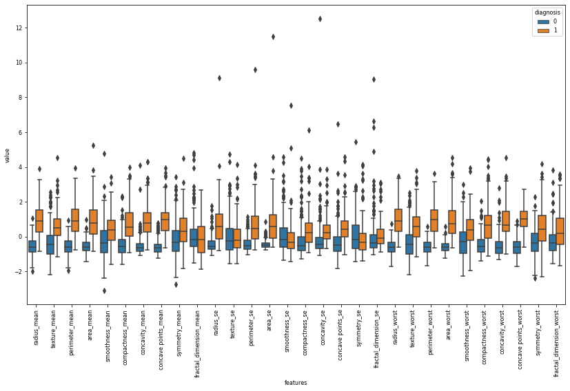

```python
boxplot(melt(df,'diagnosis'),'diagnosis')
```

#### looks better.

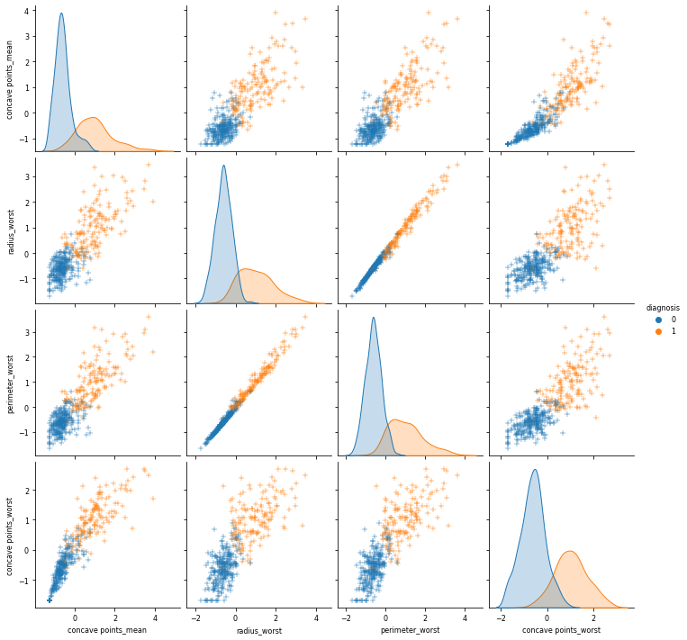

```python
pairplot(df[corr_feat],'diagnosis')
```

## Classification and Build a Model

```python
def classification_and_fit_model(model, data, predictors, outcome):
    model.fit(data[predictors], data[outcome])
    predictions = model.predict(data[predictors])
    accuracy =metrics.accuracy_score(predictions, data[outcome])
    print('Accuracy : %s' % '{0:.3%}'.format(accuracy))
    kf = KFold(n_splits=5)
    error = []
    for train, test in kf.split(data):
        train_predictors = data[predictors].iloc[train,:]
        train_target = data[outcome].iloc[train]
        model.fit(train_predictors, train_target)
        error.append(model.score(data[predictors].iloc[test,:],
                                data[outcome].iloc[test]))
        print('Cross-Validation Score : %s' % '{0:.3%}'.format(np.mean(error)))
    model.fit(data[predictors],data[outcome])
```

# Logistic Regression

```python
predictor = ['radius_mean', 'perimeter_mean', 'area_mean', 'compactness_mean', 'concave points_mean']
```

```python
outcome = 'diagnosis'
```

```python
model = LogisticRegression()
```

```python
classification_and_fit_model(model, data, predictor, outcome)
```

```
Accuracy : 89.807%
Cross-Validation Score : 78.070%
Cross-Validation Score : 82.456%
Cross-Validation Score : 86.842%
Cross-Validation Score : 88.158%
Cross-Validation Score : 89.287%
```

#### The prediction accuracy is good. What happens if we use just one predictor? Use the mean_radius:

```python
predictor1 = ['radius_mean']
```

```python
classification_and_fit_model(model, data, predictor1, outcome)
```

```
Accuracy : 87.873%
Cross-Validation Score : 74.561%
Cross-Validation Score : 78.947%
Cross-Validation Score : 84.795%
Cross-Validation Score : 86.184%
Cross-Validation Score : 86.469%
```

#### This gives a similar prediction accuracy and a cross-validation score.

#### The accuracy of the predictions are good but not great. The cross-validation scores are reasonable.

###### Can we do better with another model?

## Decision Tree

```python
model = DecisionTreeClassifier()
```

```python
classification_and_fit_model(model, data, predictor, outcome)
```

```
Accuracy : 100.000%
Cross-Validation Score : 84.211%
Cross-Validation Score : 87.281%
Cross-Validation Score : 88.304%
Cross-Validation Score : 89.693%
Cross-Validation Score : 89.984%
```

#### Here we are over-fitting the model probably due to the large number of predictors. Let use a single predictor, the obvious one is the radius of the cell.

```python
classification_and_fit_model(model, data, predictor1, outcome)
```

```
Accuracy : 95.782%
Cross-Validation Score : 75.439%
Cross-Validation Score : 76.316%
Cross-Validation Score : 81.287%
Cross-Validation Score : 81.579%
Cross-Validation Score : 81.723%
```

#### The accuracy of the prediction is much much better here. But does it depend on the predictor?

#### Using a single predictor gives a 95% prediction accuracy for this model but the cross-validation score is not that great.

## Random Forest

```python
features_mean = list(X_train_df.columns[1:11])
```

```python
model = RandomForestClassifier(n_estimators=100, min_samples_split=25, max_depth=7, max_features=2)
```

```python
classification_and_fit_model(model, data, features_mean, outcome)
```

```
Accuracy : 96.309%
Cross-Validation Score : 85.088%
Cross-Validation Score : 88.596%
Cross-Validation Score : 91.520%
Cross-Validation Score : 92.544%
Cross-Validation Score : 92.796%
```

```python
feature_importance = pd.Series(model.feature_importances_, index=features_mean).sort_values(ascending=False)
feature_importance
```

```
perimeter_mean            0.269557
area_mean                 0.166689
concave points_mean       0.164749
concavity_mean            0.162953
compactness_mean          0.078093
radius_se                 0.057925
texture_mean              0.050018
smoothness_mean           0.023722
fractal_dimension_mean    0.014526
symmetry_mean             0.011767
dtype: float64
```

```python
model = RandomForestClassifier(n_estimators=100, min_samples_split=25, max_depth=7, max_features=2)
```

```python
classification_and_fit_model(model, data, predictor, outcome)
```

```
Accuracy : 94.200%
Cross-Validation Score : 83.333%
Cross-Validation Score : 87.281%
Cross-Validation Score : 90.643%
Cross-Validation Score : 91.009%
Cross-Validation Score : 91.391%
```

#### What happens if we use a single predictor as before?

```python
model = RandomForestClassifier(n_estimators=100)
```

```python
classification_and_fit_model(model, data, predictor1, outcome)
```

```
Accuracy : 95.782%
Cross-Validation Score : 75.439%
Cross-Validation Score : 76.316%
Cross-Validation Score : 80.994%
Cross-Validation Score : 81.140%
Cross-Validation Score : 81.372%
```